# FIVB Beach Volleyball Historic Top 8 Teams Analysis

Tyler Widdison

Dec 2019

# 1 Project description

## 1.1 Source of data set

This data set was webscrapped from 2 sources. First from FIVB Beach competiton database. http://www.fivb.org/EN/BeachVolleyball/Competitions/Competitions.htm Second, FIVB Beach rankings from http://www.fivb.org/Vis/Public/JS/Beach/SeasonRank.aspx?Gender=1&id=BTechPlayW&Date=20191001. Numerous more links were accessed between these two links. But ultimatly I was able to access the data I was looking for. I will provide the final CSV I used for this project. I did end up doing a lot more work to get this final csv than I originally planned.

**^Note: The team variable is already melted. One match is listed twice. For example if it was USA vs GER, I have the ‘team’ be ‘USA’ and the opp team be ‘GER’, the next time this match appears the team is ‘GER’ and the opp is ‘USA’. I did this so I can look at specific teams results. I wouldn’t be able to get a true reading on how many matches 1 team played if I had kept it seperated. I call this ‘The focus team.’**

## 1.2 Data dictionary

| Variable Name | Description |
| --- | --- |
| *no* | Match number of specific tournament |
| *date* | Date of match |
| *time* | Time of match |
| *court* | Court match is played on |
| *result* | Result of the played match |
| *duration* | Duration of the played match |
| *tourn* | Tournament name |
| *year* | Year of tournament |
| *phase* | Phase of tournament the match was played |
| *winning_team* | Winning team of the match |
| *losing_team* | Losing team of the match |
| *gender* | Gender of teams |
| *team* | The focus team |
| *team_country* | The focus team country |
| *team_rank* | The rank of the focus teams at the end of that played year |
| *opp* | The focus teams opponent |
| *opp_country* | The focus teams opponent country |
| *matches_played* | This is always listed as ‘1’. Each row is one match. I wanted to be able to sum the total of matches played for my hypothesis |
| *team_match_won* | If the focus team had won the match this will be a ‘1’ otherwise it is a ‘0’ |
| *opp_match_won* | If the opponent team had won the match this will be a ‘1’ otherwise it is a ‘0’ |
| *team_player_1* | First listed player in the played match for the focus team |
| *team_player_2* | Second listed player in the played match for the focus team |
| *opp_player_1* | First listed player in the played match for the opp team |
| *opp_player_2* | Second listed player in the played match for the opp team |

Each variable was considered and ultimatley I decided to do my hypothesis on my level. The main variables used were: date, court, year, gender, team, team_rank, matches_played, team_match_won, team_player_1 and team_player_2.

# 2 Preparation of Data

There was a lot of data munging I had to do in order to get to my final hypothesis. I had to change classes, column names, get rid of columns, replace strings, melt the players variable and get the hour of the time. This is a few things I did. There was more munging I originally did before I came to my final hypothesis.

## 2.1 FIVB data

I webscrapped all the data from the FIVB websites. With the amount of links (about 750) one can guess there was errors I found. I had to nix all the matches that ended in a ‘injury’ result. Player names were different across multiple tournaments, time of day was bad in some cases. For example: 01:00, 02:00, 04:00, 04:57 were all times I had to make correct. There were a couple of matches which still had the live score on the result. For example: LIVE (21-12, 13-15). It shouldn’t have that ‘LIVE’ potion on the result.

## 2.2 Ranking of teams data

I webscrapped the rankings on Oct 1 of each year. After consulting with a friend we decided Oct 1 would be the final rank for that played year. Jan - Oct. The naming convention between the rankings and the FIVB schedule were different. So I had to spend some time doctoring in Excel in order to get the names, and rankings, of the player in the top 8 correct for each year. Also there were special charecters that caused some issues that I dealt with in this way:

```r
unescape_html <- function(str){
  xml2::xml_text(xml2::read_html(paste0("<x>", str, "</x>")))
}
```

## 2.3 Final web scrapped data summary

```r
summary(df)
```

```
##     match_no           date                time               court
##  Min.   :  1.00   Min.   :2001-04-04   Length:226126      Min.   :1.00
##  1st Qu.: 12.00   1st Qu.:2006-07-19   Class :character   1st Qu.:1.00
##  Median : 25.00   Median :2010-08-24   Mode  :character   Median :2.00
##  Mean   : 29.38   Mean   :2011-02-19                      Mean   :2.45
##  3rd Qu.: 45.00   3rd Qu.:2016-03-18                      3rd Qu.:3.00
##  Max.   :136.00   Max.   :2019-11-09                      Max.   :8.00
##  NA's   :2086                                             NA's   :105034
##     duration        tourn                year        tourn_rank
##  Min.   :  300   Length:226126      Min.   :2001   Min.   :  7.20
##  1st Qu.: 2100   Class :character   1st Qu.:2006   1st Qu.: 18.63
##  Median : 2400   Mode  :character   Median :2010   Median : 23.41
##  Mean   : 2538                      Mean   :2011   Mean   : 49.55
##  3rd Qu.: 2940                      3rd Qu.:2016   3rd Qu.: 41.50
##  Max.   :14940                      Max.   :2019   Max.   :479.09
##
##  winning_team       losing_team           gender
##  Length:226126      Length:226126      Length:226126
##  Class :character   Class :character   Class :character
##  Mode  :character   Mode  :character   Mode  :character
##
##
##
##
##      team           team_country         team_rank
##  Length:226126      Length:226126      Min.   :   1.00
##  Class :character   Class :character   1st Qu.:  14.00
##  Mode  :character   Mode  :character   Median :  35.00
##                                        Mean   :  66.84
##                                        3rd Qu.:  84.00
##                                        Max.   :1976.00
##                                        NA's   :18
##  team_match_score   team_game_one   team_game_two   team_game_three
##  Length:226126      Min.   : 0.00   Min.   : 0.00   Min.   : 0.000
##  Class :character   1st Qu.:17.00   1st Qu.:17.00   1st Qu.: 0.000
##  Mode  :character   Median :21.00   Median :21.00   Median : 0.000
##                     Mean   :18.89   Mean   :18.86   Mean   : 4.496
##                     3rd Qu.:21.00   3rd Qu.:21.00   3rd Qu.:12.000
##                     Max.   :41.00   Max.   :42.00   Max.   :35.000
##
```

[output cut: 33 more lines]

```
##  Min.   : 3.00    Min.   : 3.00        team_player_1:113063
##  1st Qu.:35.00    1st Qu.:35.00        team_player_2:113063
##  Median :42.00    Median :42.00
##  Mean   :42.24    Mean   :42.24
##  3rd Qu.:49.00    3rd Qu.:49.00
##  Max.   :85.00    Max.   :85.00
##
##     player          game_three_amount    phase                hour
##  Length:226126      Min.   :0.0000    Length:226126      Min.   : 8.00
##  Class :character   1st Qu.:0.0000    Class :character   1st Qu.:11.00
##  Mode  :character   Median :0.0000    Mode  :character   Median :13.00
##                     Mean   :0.3311                       Mean   :13.18
##                     3rd Qu.:1.0000                       3rd Qu.:16.00
##                     Max.   :1.0000                       Max.   :23.00
##                                                          NA's   :28864
```

# 3 Exploring the data

I ended up spending time exploring areas I didn’t dive deeper into. A big part was trying to figure out how I could use ‘score_difference’ and how likely a team was to win the match as a varaible for a hypothesis. Other areas I explored:

## 3.1 Places explored

- Players density charts

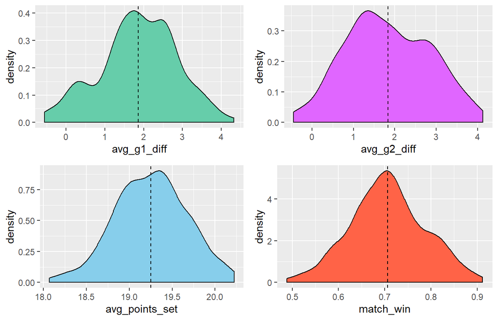

- Points difference in game 1 and match won

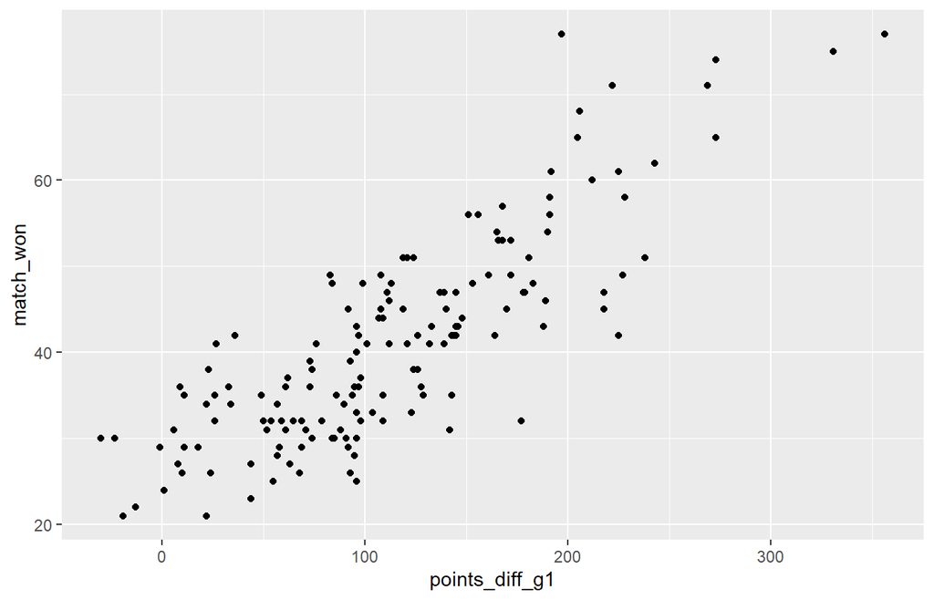

- Matches played per year for mens top 8

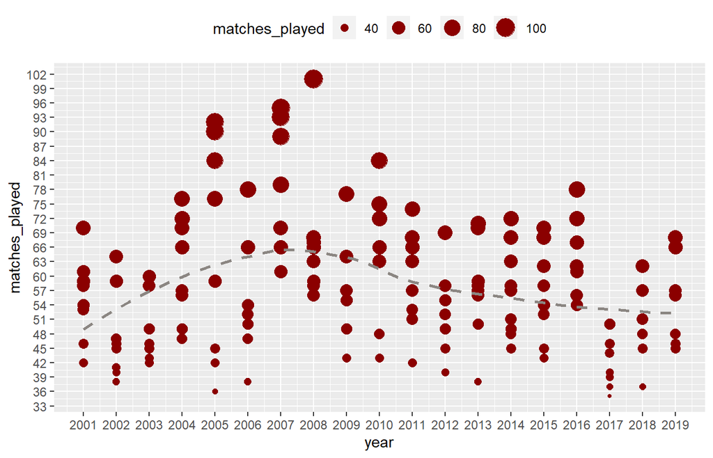

- Point diff and correlation value

```
##    (Intercept) points_diff_g1
##    51.67797528     0.04305242
```

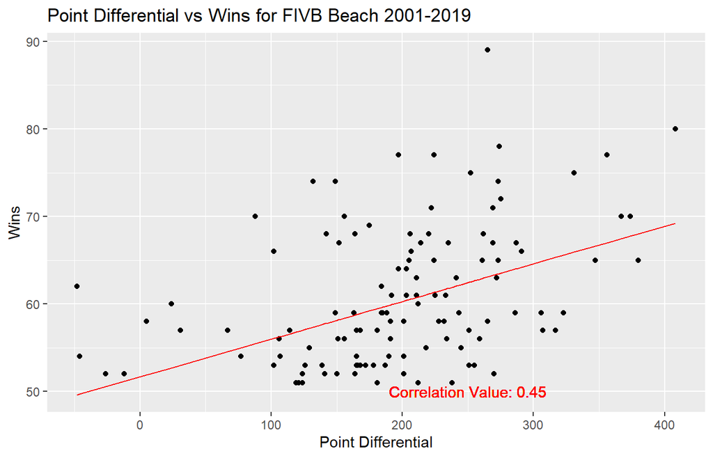

- Teams ranked 20 and higher, coorlation of match wins based on average point diff in game 1

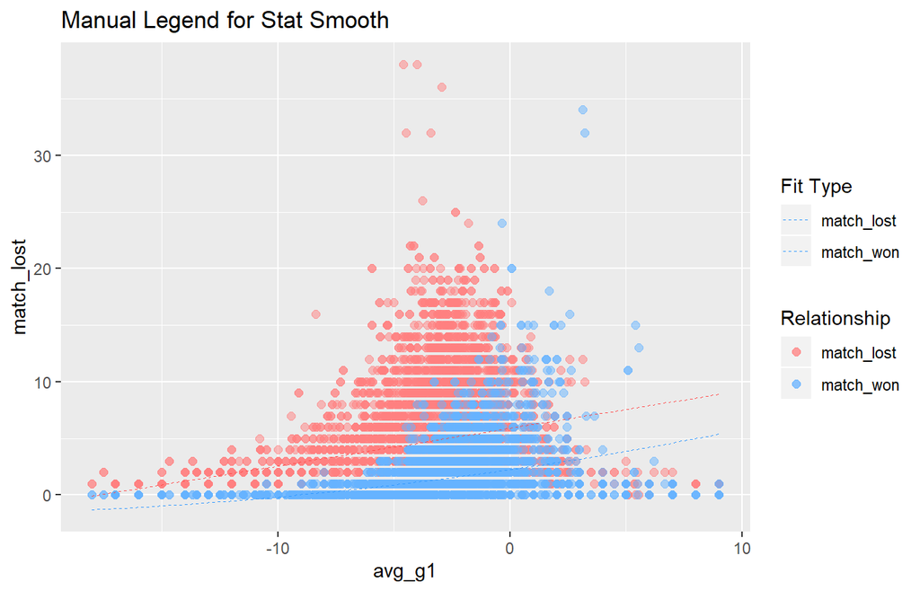

- Tougher tournaments have longer matches

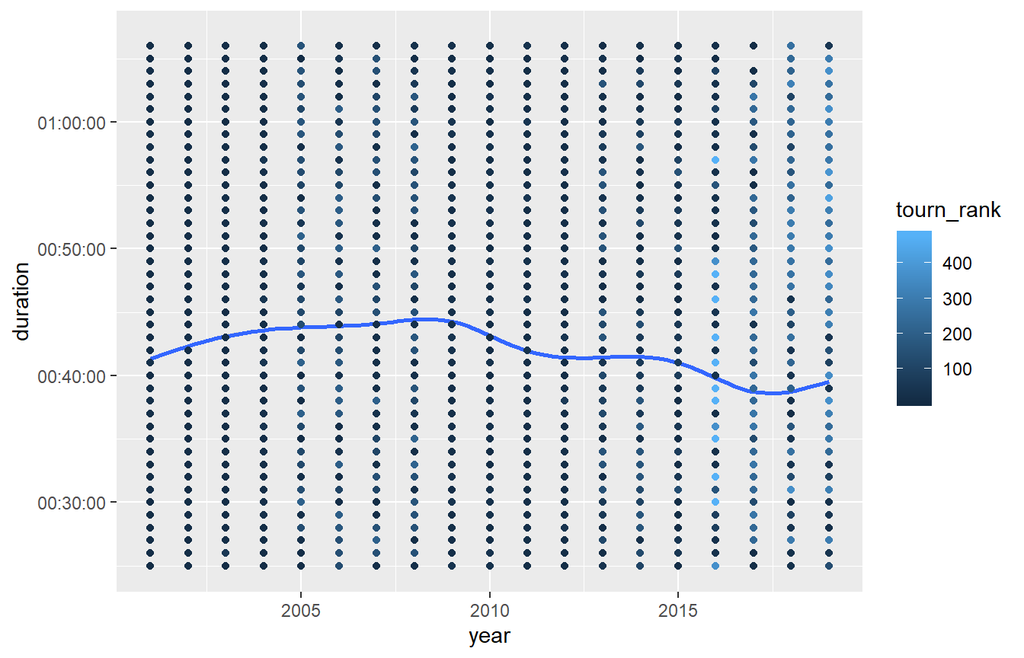

- Toughest year to play beach volleyball?

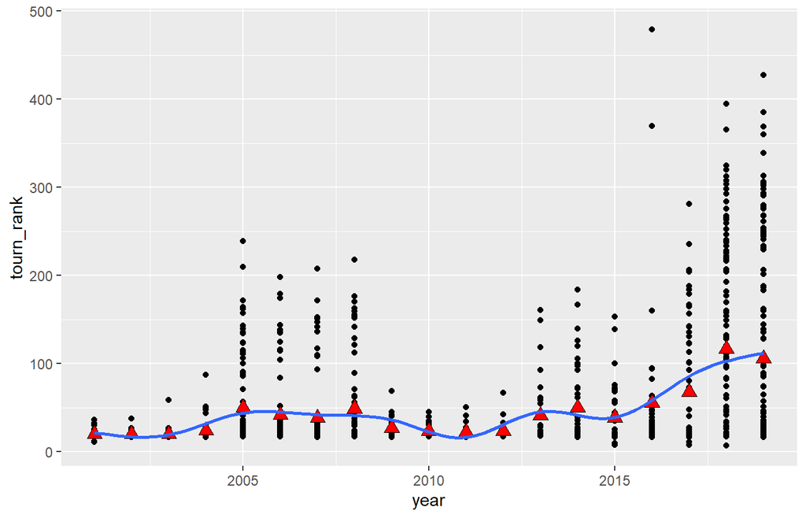

- Which year avg the longest match duration?

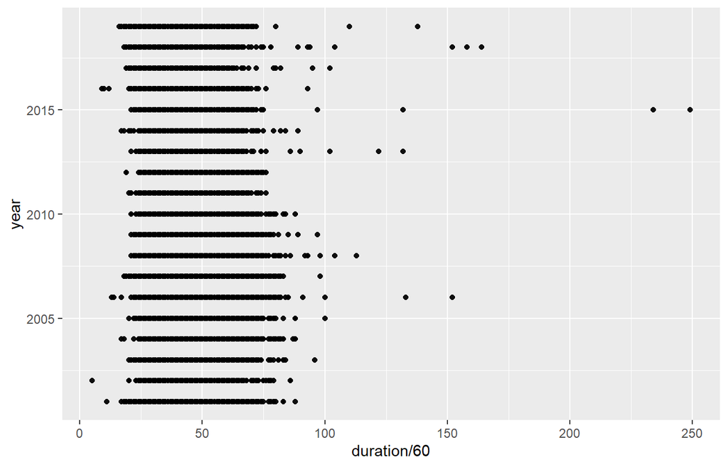

- Men teams ranked 1st played how well?

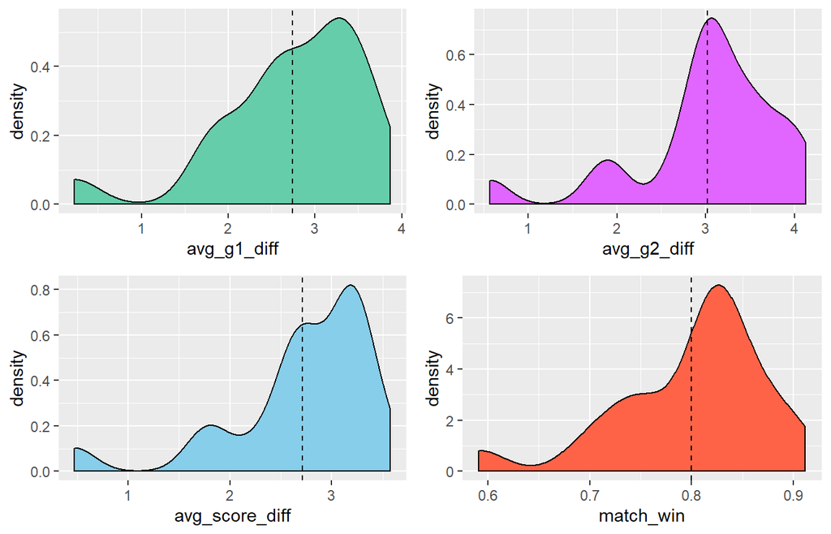

- All first ranked teams score diff

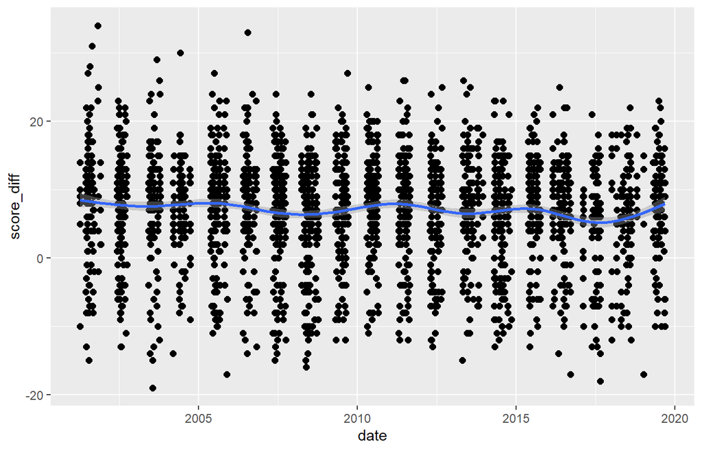

- All first place team final points difference

[figure not shown]

- Point difference in first place teams

```
## (Intercept)  score_diff
## 43.50886944  0.07202652
```

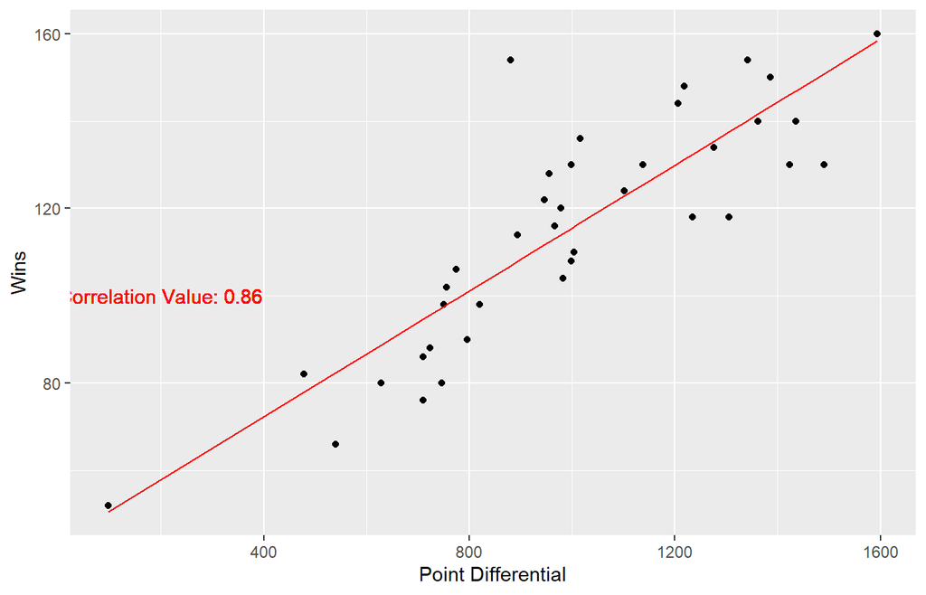

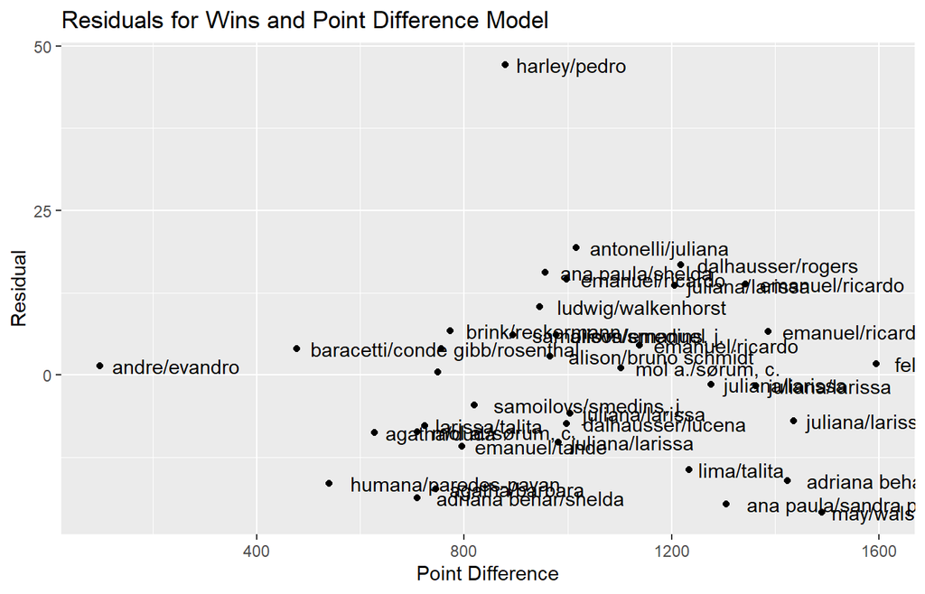

- Getting the data put into this

```r
all_player_df <- df %>%
  dplyr::group_by(player, hour, team, team_country, tourn_rank, tourn, date, phase, year, match_no, court, time, team_rank, gender, opp, opp_team_rank) %>%
  dplyr::summarise(total_matches = sum(matches_played),
                   match_won = sum(team_match_won),
                   match_lost = sum(matches_played - team_match_won),
                   match_win = match_won / (match_won + match_lost),
                   total_set_threes = sum(game_three_amount),
                   total_sets_played = (total_matches + total_matches + total_set_threes),
                   rank = sum(team_rank))

all_player_df$total_matches<-suppressWarnings(as.character(all_player_df$total_matches))

all_player_df$total_matches <- str_replace(all_player_df$total_matches, '2', '1') #Each row is one match. When there was a team with the same name twice, widdison/widdison, it would say they played in 2 matches for that team. So I did a quick switch to 1.

all_player_df$total_matches <- suppressWarnings(as.integer(all_player_df$total_matches))

df_men <- all_player_df %>%
  dplyr::filter(gender == 'm' & team_rank <= 8)

df_women <- all_player_df %>%
  dplyr::filter(gender == 'w' & team_rank <= 8)
```

# 4 Machine learning

## 4.1 Decided predictors

[figure not shown]

```r
f <- df_men %>%
  dplyr::group_by(hour, court) %>%
  dplyr::summarise(total_matches = sum(total_matches),
                   match_win_perce = sum((match_won) / total_matches))

f <- na.omit(f)
f <- f %>% dplyr::filter(total_matches >= 29) #I wanted to get a sample size with more than 29 matches

formula <- match_win_perce ~hour + court


mhlm <- glm(formula, data=f)

prob <- predict(mhlm, newdata=f, type="response")
prob <- round(prob,3)
f$prob <- prob


f %>%
  ggplot(aes(court, hour)) +
  geom_point(aes(color = prob), size = 7, alpha = 0.5) +
  scale_size(range = c(.5, 9)) +
  scale_y_continuous(breaks = seq(8, 22, by = 1)) +
  labs(title = 'FIVB top 8 team probability of winning by court and hour',
       subtitle = 'Data from 2009 - 2019',
       size = 'Probability%',
       color ='Probability',
       x = 'Court',
       y = 'Hour')+
  scale_color_viridis(option="C")+
  scale_x_continuous(breaks = 1:6)
```

```r
f$prob<-format(round(f$prob,3))
f$match_win_perce <- NULL
f$total_matches <- NULL

f<-f[order(-prob),]
colnames(f) <- c('Hour', 'Court', 'Probablity')
kable(f) %>%
  kable_styling(bootstrap_options = "striped", full_width = F, position = 'left', fixed_thead = T) %>%
  scroll_box(width = '200px', height='500px')
```

| Hour | Court | Probablity |
| --- | --- | --- |
| 11 | 5 | 0.808 |
| 15 | 6 | 0.806 |
| 8 | 4 | 0.803 |
| 12 | 5 | 0.801 |
| 9 | 4 | 0.796 |
| 13 | 5 | 0.795 |
| 10 | 4 | 0.790 |
| 11 | 4 | 0.783 |
| 8 | 3 | 0.778 |
| 12 | 4 | 0.777 |
| 16 | 5 | 0.775 |
| 9 | 3 | 0.772 |
| 13 | 4 | 0.770 |
| 10 | 3 | 0.765 |
| 14 | 4 | 0.764 |
| 11 | 3 | 0.758 |
| 15 | 4 | 0.757 |
| 8 | 2 | 0.753 |
| 12 | 3 | 0.752 |
| 16 | 4 | 0.750 |
| 9 | 2 | 0.747 |
| 13 | 3 | 0.745 |
| 17 | 4 | 0.744 |
| 10 | 2 | 0.740 |
| 14 | 3 | 0.739 |
| 18 | 4 | 0.737 |
| 11 | 2 | 0.734 |
| 15 | 3 | 0.732 |
| 19 | 4 | 0.731 |
| 8 | 1 | 0.729 |
| 12 | 2 | 0.727 |
| 16 | 3 | 0.726 |
| 9 | 1 | 0.722 |
| 13 | 2 | 0.721 |
| 17 | 3 | 0.719 |
| 10 | 1 | 0.715 |
| 14 | 2 | 0.714 |
| 18 | 3 | 0.713 |
| 11 | 1 | 0.709 |
| 15 | 2 | 0.707 |
| 19 | 3 | 0.706 |
| 12 | 1 | 0.702 |
| 16 | 2 | 0.701 |
| 13 | 1 | 0.696 |
| 17 | 2 | 0.694 |
| 14 | 1 | 0.689 |
| 18 | 2 | 0.688 |
| 15 | 1 | 0.683 |
| 19 | 2 | 0.681 |
| 16 | 1 | 0.676 |
| 17 | 1 | 0.670 |
| 18 | 1 | 0.663 |
| 19 | 1 | 0.656 |
| 20 | 1 | 0.650 |
| 21 | 1 | 0.643 |

# 5 *Conclusion*